# Abalones Data Analysis

Kramarczyk, John

```
## 'data.frame':    1036 obs. of  8 variables:
##  $ SEX   : Factor w/ 3 levels "F","I","M": 2 2 2 2 2 2 2 2 2 2 ...
##  $ LENGTH: num  5.57 3.67 10.08 4.09 6.93 ...
##  $ DIAM  : num  4.09 2.62 7.35 3.15 4.83 ...
##  $ HEIGHT: num  1.26 0.84 2.205 0.945 1.785 ...
##  $ WHOLE : num  11.5 3.5 79.38 4.69 21.19 ...
##  $ SHUCK : num  4.31 1.19 44 2.25 9.88 ...
##  $ RINGS : int  6 4 6 3 6 6 5 6 5 6 ...
##  $ CLASS : Factor w/ 5 levels "A1","A2","A3",..: 1 1 1 1 1 1 1 1 1 1 ...
```

*##### Section 1: Summarizing the data.*

(1)(a) Use *summary()* to obtain and present descriptive statistics from mydata. Use *table()* to present a frequency table using CLASS and RINGS. There should be 115 cells in the table you present.

```
##  SEX         LENGTH           DIAM            HEIGHT          WHOLE
##  F:326   Min.   : 2.73   Min.   : 1.995   Min.   :0.525   Min.   :  1.625
##  I:329   1st Qu.: 9.45   1st Qu.: 7.350   1st Qu.:2.415   1st Qu.: 56.484
##  M:381   Median :11.45   Median : 8.925   Median :2.940   Median :101.344
##          Mean   :11.08   Mean   : 8.622   Mean   :2.947   Mean   :105.832
##          3rd Qu.:13.02   3rd Qu.:10.185   3rd Qu.:3.570   3rd Qu.:150.319
##          Max.   :16.80   Max.   :13.230   Max.   :4.935   Max.   :315.750
##      SHUCK              RINGS        CLASS        VOLUME
##  Min.   :  0.5625   Min.   : 3.000   A1:108   Min.   :  3.612
##  1st Qu.: 23.3006   1st Qu.: 8.000   A2:236   1st Qu.:163.545
##  Median : 42.5700   Median : 9.000   A3:329   Median :307.363
##  Mean   : 45.4396   Mean   : 9.993   A4:188   Mean   :326.804
##  3rd Qu.: 64.2897   3rd Qu.:11.000   A5:175   3rd Qu.:463.264
##  Max.   :157.0800   Max.   :25.000            Max.   :995.673
##      RATIO
##  Min.   :0.06734
##  1st Qu.:0.12241
##  Median :0.13914
##  Mean   :0.14205
##  3rd Qu.:0.15911
##  Max.   :0.31176
```

```
##
##       A1  A2  A3  A4  A5
##   3    9   0   0   0   0
##   4    8   0   0   0   0
##   5   24   0   0   0   0
##   6   67   0   0   0   0
##   7    0  91   0   0   0
##   8    0 145   0   0   0
##   9    0   0 182   0   0
##   10   0   0 147   0   0
##   11   0   0   0 125   0
##   12   0   0   0  63   0
##   13   0   0   0   0  48
##   14   0   0   0   0  35
##   15   0   0   0   0  27
##   16   0   0   0   0  15
##   17   0   0   0   0  13
##   18   0   0   0   0   8
##   19   0   0   0   0   8
##   20   0   0   0   0   6
##   21   0   0   0   0   4
##   22   0   0   0   0   1
##   23   0   0   0   0   7
##   24   0   0   0   0   2
##   25   0   0   0   0   1
```

**Question (): Briefly discuss the variable types and distributional implications such as potential skewness and outliers.**

*Answer:*

*There are 3 different variable types: 1) factor or nominal (Sex and Class), 2) numeric or continuous (Length, Diameter, Height, Whole, Shuck, Volume, and Ratio, and 3) integer or discrete (Rings).*

*There seems to be an even distribution among the Sex types (Female, Infant, Male). Height, Whole, and Volume appear to be symmetric; Length and Diam appear to be moderately skewed to the left; Shuck and Ratio appear to be moderately skewed to the right; and Rings appears to be highly skewed to the right. For example, Shuck, Rings, and Ratio have max values well above the mean, indicating outliers and thus non-normal distribution, potentially skewing the data to the right.*

(1)(b) Generate a table of counts using SEX and CLASS. Add margins to this table (Hint: There should be 15 cells in this table plus the marginal totals. Apply *table()* first, then pass the table object to *addmargins()* (Kabacoff Section 7.2 pages 144-147)). Lastly, present a barplot of these data; ignoring the marginal totals.

```
##
##         A1   A2   A3   A4   A5  Sum
##   F      5   41  121   82   77  326
##   I     91  133   65   21   19  329
##   M     12   62  143   85   79  381
##   Sum  108  236  329  188  175 1036
```

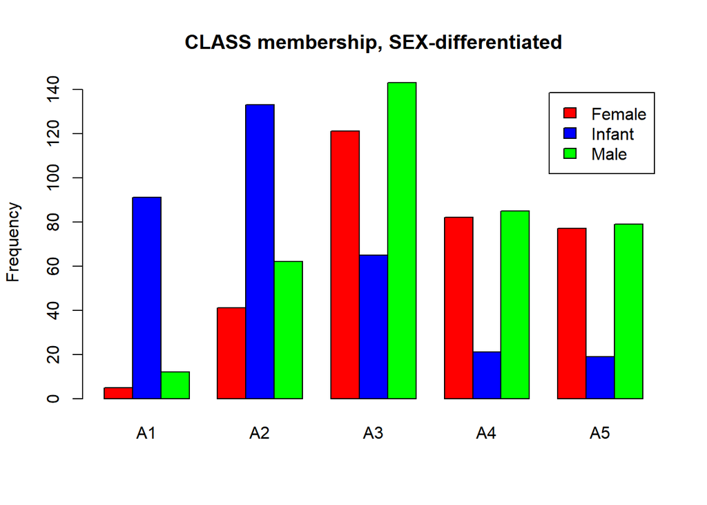

**Essay Question : Discuss the sex distribution of abalones. What stands out about the distribution of abalones by CLASS?**

*Answer: CLASS classifies sex by age, or the number of rings in each abalone, with A1 being the youngest, and A5 being the oldest. As expected, INFANTs are mostly distributed in the younger age classifications (A1 and A2) and least distributed in the older classifications (A4 and A5). MALE and FEMALE are mostly distributed in the middle (A3) with more MALEs overall, but both hold very similar shapes throughout each CLASS. Also, as MALE and FEMALE become older, their levels become more even.*

*As expected, most abalone life is sustained in the early to mid-ranges (A2 and A3) and taper off as they get older (A4 and A5), perhaps indicating a healthy population. However, it is interesting to note that there are still INFANTs in the A4 and A5 CLASS, perhaps indicating that RINGs may not be the most accurate representation of age; or there is a common growth anomaly among the data the needs to be uncovered; or there are outside environmental factors that negatively impacts abalone growth*

(1)(c) Select a simple random sample of 200 observations from “mydata” and identify this sample as “work.” Use *set.seed(123)* prior to drawing this sample. Do not change the number 123. Note that *sample()* “takes a sample of the specified size from the elements of x.” We cannot sample directly from “mydata.” Instead, we need to sample from the integers, 1 to 1036, representing the rows of “mydata.” Then, select those rows from the data frame (Kabacoff Section 4.10.5 page 87).

Using “work”, construct a scatterplot matrix of variables 2-6 with *plot(work[, 2:6])* (these are the continuous variables excluding VOLUME and RATIO). The sample “work” will not be used in the remainder of the assignment.

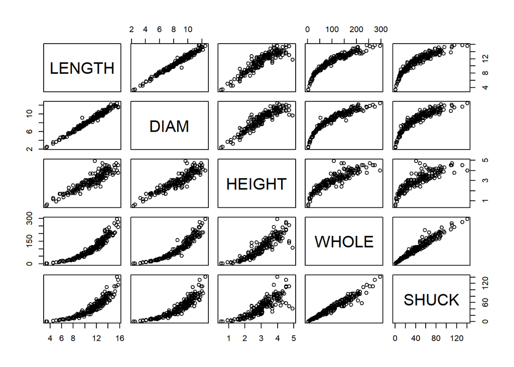

*##### Section 2: Summarizing the data using graphics.*

(2)(a) Use “mydata” to plot WHOLE versus VOLUME. Color code data points by CLASS.

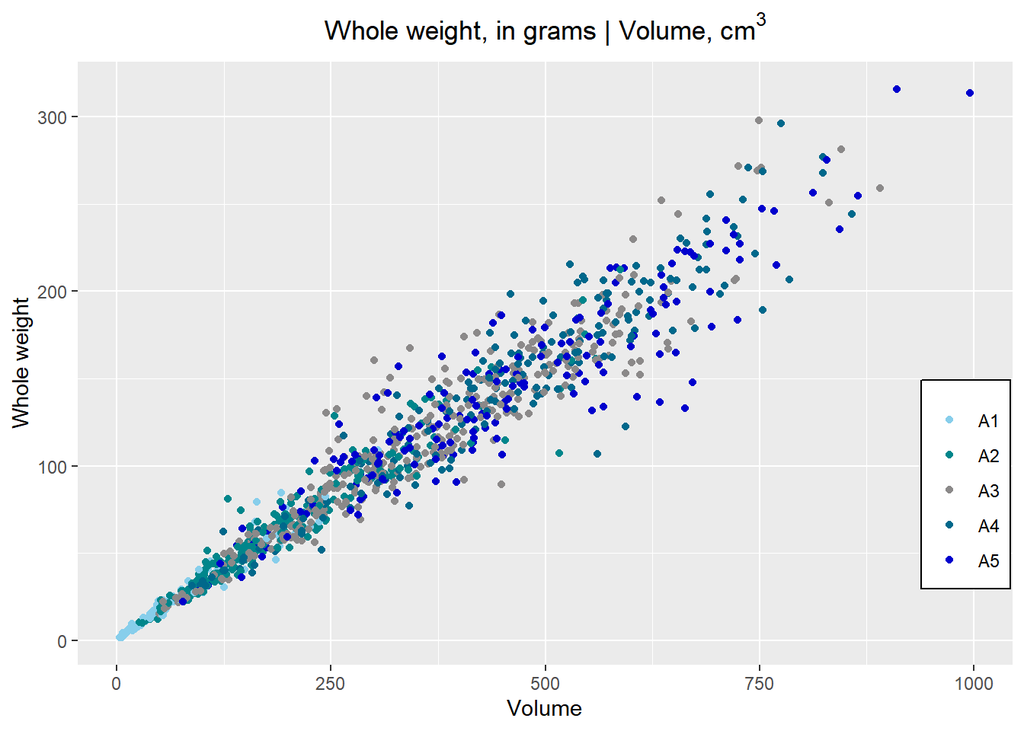

(2)(b) Use “mydata” to plot SHUCK versus WHOLE with WHOLE on the horizontal axis. Color code data points by CLASS. As an aid to interpretation, determine the maximum value of the ratio of SHUCK to WHOLE. Add to the chart a straight line with zero intercept using this maximum value as the slope of the line. If you are using the ‘base R’ *plot()* function, you may use *abline()* to add this line to the plot. Use *help(abline)* in R to determine the coding for the slope and intercept arguments in the functions. If you are using ggplot2 for visualizations, *geom_abline()* should be used.

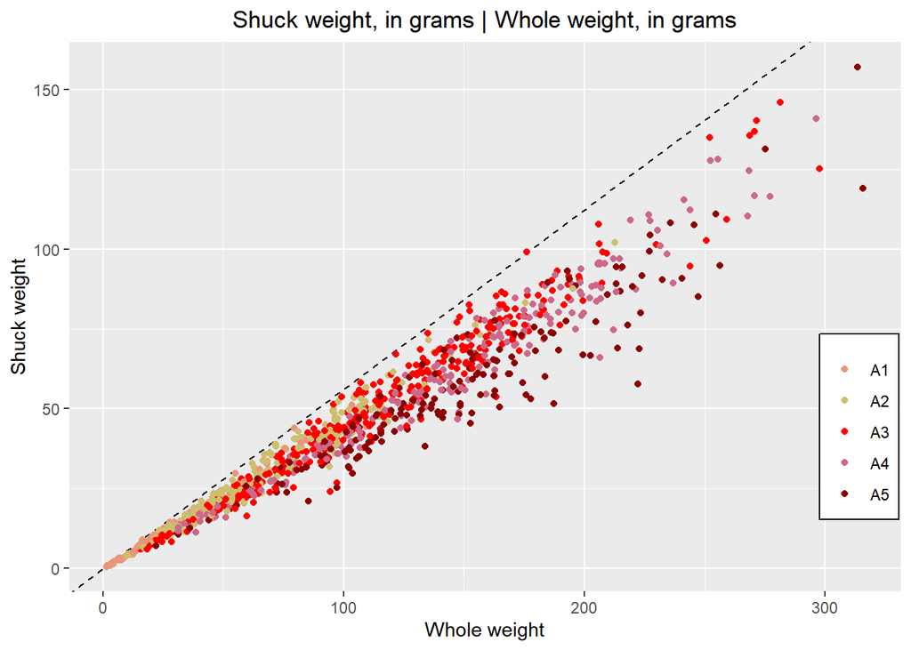

**Essay Question : How does the variability in this plot differ from the plot in (a)? Compare the two displays. Keep in mind that SHUCK is a part of WHOLE. Consider the location of the different age classes.**

*Answer: CLASS is similar between the two plots as both plots show positive trends and correlations. As VOLUME and WHOLE weight increase, WHOLE weight and SHUCK weight increase, respectively. Both plots show that the younger classes (A1 and A2) are closer to 0, and the older classes (A3, A4, and A5) are closer to the mean VOLUME and WHOLE weight in both plots. This makes sense since INFANTs begin with less weight but naturally gain more with age.*

*However, in plot (a), there does not appear to be significant differences between the ratio of WHOLE weight and VOLUME among the different age groups. Plot (b), on the other hand, has less variability and a clearer distinction among the ages (CLASS) and WEIGHT, revealing an interesting trend that the older abalone (A5) have lower SHUCK and WHOLE weight than the younger abalone (A1 thru A4), the second to oldest abalone (A4) have lower SHUCK and WHOLE weight than the younger abalone (A1 thru A3), and so forth. Perhaps this reveals that the variability in whole weight and volume is due to the weight of the shell*

*### Section 3: Getting insights about the data using graphs.*

(3)(a) Use “mydata” to create a multi-figured plot with histograms, boxplots and Q-Q plots of RATIO differentiated by sex. This can be done using *par(mfrow = c(3,3))* and base R or *grid.arrange()* and ggplot2. The first row would show the histograms, the second row the boxplots and the third row the Q-Q plots. Be sure these displays are legible.

```
## 'data.frame':    1036 obs. of  10 variables:
##  $ SEX   : Factor w/ 3 levels "F","I","M": 2 2 2 2 2 2 2 2 2 2 ...
##  $ LENGTH: num  5.57 3.67 10.08 4.09 6.93 ...
##  $ DIAM  : num  4.09 2.62 7.35 3.15 4.83 ...
##  $ HEIGHT: num  1.26 0.84 2.205 0.945 1.785 ...
##  $ WHOLE : num  11.5 3.5 79.38 4.69 21.19 ...
##  $ SHUCK : num  4.31 1.19 44 2.25 9.88 ...
##  $ RINGS : int  6 4 6 3 6 6 5 6 5 6 ...
##  $ CLASS : Factor w/ 5 levels "A1","A2","A3",..: 1 1 1 1 1 1 1 1 1 1 ...
##  $ VOLUME: num  28.7 8.1 163.4 12.2 59.7 ...
##  $ RATIO : num  0.15 0.147 0.269 0.185 0.165 ...
```

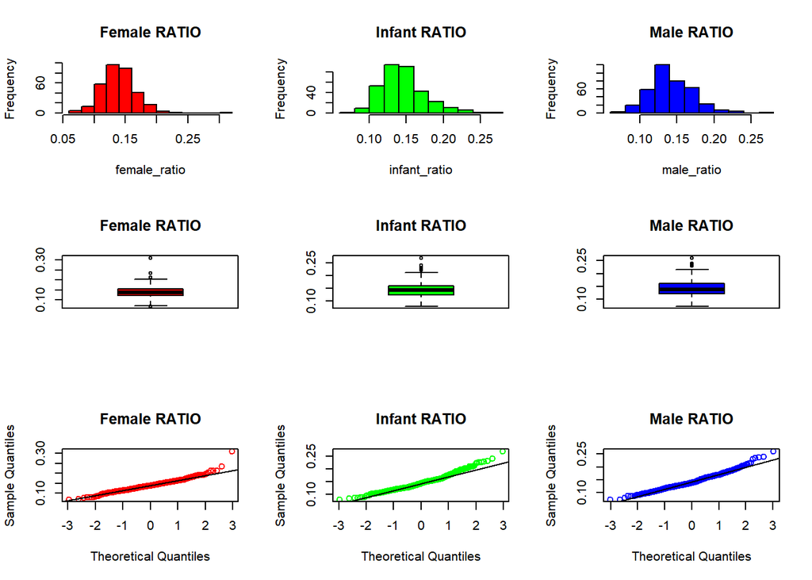

**Essay Question : Compare the displays. How do the distributions compare to normality? Take into account the criteria discussed in the sync sessions to evaluate non-normality.**

*Answer: For the most part, all displays appear normally distributed. However, they are all non-normal. The histograms are non-normal because each SEX skews slightly to the right, showing a right tail, likely due to outliers. The boxplots reveal several outliers in each SEX, again with right tails, confirming the non-normal distribution seen in the histograms. The Q-Q plots are non-normally distributed too as each sex has outliers at the beginning and end of the qqlines, mostly at the end, further revealing a right skew/tail as seen in the histograms and boxplots.*

(3)(b) The boxplots in (3)(a) indicate that there are outlying RATIOs for each sex. *boxplot.stats()* can be used to identify outlying values of a vector. Present the abalones with these outlying RATIO values along with their associated variables in “mydata”. Display the observations by passing a data frame to the kable() function. Basically, we want to output those rows of “mydata” with an outlying RATIO, but we want to determine outliers looking separately at infants, females and males.

| SEX | LENGTH | DIAM | HEIGHT | WHOLE | SHUCK | RINGS | CLASS | VOLUME | RATIO |
| --- | --- | --- | --- | --- | --- | --- | --- | --- | --- |
| I | 10.080 | 7.350 | 2.205 | 79.37500 | 44.00000 | 6 | A1 | 163.364040 | 0.2693371 |
| I | 4.305 | 3.255 | 0.945 | 6.18750 | 2.93750 | 3 | A1 | 13.242072 | 0.2218308 |
| I | 2.835 | 2.730 | 0.840 | 3.62500 | 1.56250 | 4 | A1 | 6.501222 | 0.2403394 |
| I | 6.720 | 4.305 | 1.680 | 22.62500 | 11.00000 | 5 | A1 | 48.601728 | 0.2263294 |
| I | 5.040 | 3.675 | 0.945 | 9.65625 | 3.93750 | 5 | A1 | 17.503290 | 0.2249577 |
| I | 3.360 | 2.310 | 0.525 | 2.43750 | 0.93750 | 4 | A1 | 4.074840 | 0.2300704 |
| I | 6.930 | 4.725 | 1.575 | 23.37500 | 11.81250 | 7 | A2 | 51.572194 | 0.2290478 |
| I | 9.135 | 6.300 | 2.520 | 74.56250 | 32.37500 | 8 | A2 | 145.027260 | 0.2232339 |
| M | 13.440 | 10.815 | 1.680 | 130.25000 | 63.73125 | 10 | A3 | 244.194048 | 0.2609861 |
| M | 10.500 | 7.770 | 3.150 | 132.68750 | 61.13250 | 9 | A3 | 256.992750 | 0.2378764 |
| M | 10.710 | 8.610 | 3.255 | 160.31250 | 70.41375 | 9 | A3 | 300.153640 | 0.2345924 |
| M | 12.285 | 9.870 | 3.465 | 176.12500 | 99.00000 | 10 | A3 | 420.141472 | 0.2356349 |
| M | 11.550 | 8.820 | 3.360 | 167.56250 | 78.27187 | 10 | A3 | 342.286560 | 0.2286735 |
| F | 7.980 | 6.720 | 2.415 | 80.93750 | 40.37500 | 7 | A2 | 129.505824 | 0.3117620 |
| F | 15.330 | 11.970 | 3.465 | 252.06250 | 134.89812 | 10 | A3 | 635.827846 | 0.2121614 |
| F | 11.550 | 7.980 | 3.465 | 150.62500 | 68.55375 | 10 | A3 | 319.365585 | 0.2146560 |
| F | 13.125 | 10.290 | 2.310 | 142.00000 | 66.47062 | 9 | A3 | 311.979938 | 0.2130606 |
| F | 11.445 | 8.085 | 3.150 | 139.81250 | 68.49062 | 9 | A3 | 291.478399 | 0.2349767 |
| F | 12.180 | 9.450 | 4.935 | 133.87500 | 38.25000 | 14 | A5 | 568.023435 | 0.0673388 |

**Essay Question : What are your observations regarding the results in (3)(b)?**

*Answer: Every SEX class has mild outliers, but extreme outliers are found in 1 INFANT and 2 FEMALEs with RATIOs of 0.2693371, 0.3117620, and 0.0673388, respectively. For example, larger categories like LENGTH, WHOLE weight, and VOLUME are closely related with older abalones (A2 thru A5) except for the extreme outliers found in 1 INFANT and 2 FEMALES. All of this is congruent with the analyses of the graphs above which indicates the need for further analysis.*

*### Section 4: Getting insights about possible predictors.*

(4)(a) With “mydata,” display side-by-side boxplots for VOLUME and WHOLE, each differentiated by CLASS There should be five boxes for VOLUME and five for WHOLE. Also, display side-by-side scatterplots: VOLUME and WHOLE versus RINGS. Present these four figures in one graphic: the boxplots in one row and the scatterplots in a second row. Base R or ggplot2 may be used.

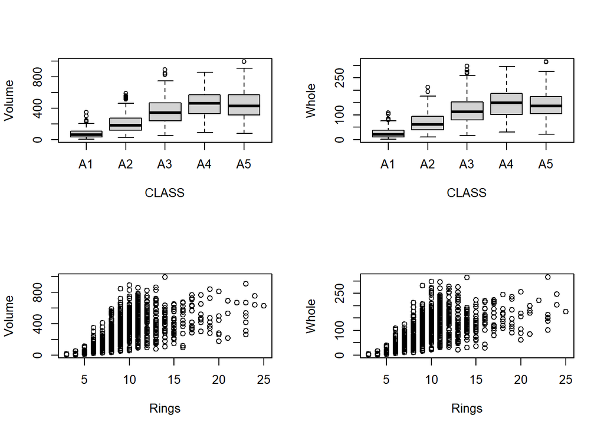

**Essay Question How well do you think these variables would perform as predictors of age? Explain.**

*Answer: For the most part, VOLUME, WHOLE, and RINGS appear to be reliable predictors of age because as VOLUME and WHOLE weight increases, so do the age categories of CLASS and RINGs. This reveals a positive and predictive correlation between these variables parallel to normal lifespans of various species that lose weight with more senior age. Moreover, it is interesting to note that RINGs begin to decline after 10+ RINGs and run thin at around 18-20 RINGs. This seems to further indicate that the normal, or predictive, lifespan of abalone range around these data points and that RINGs beyond the 15-20 range, although possible, are indeed outliers because they may not be common among abalone. This may also indicate anomalies in the harvesting and sampling procedures, suggesting a need to reexamine these processes*

*### Section 5: (12 points) Getting insights regarding different groups in the data.*

(5)(a) Use *aggregate()* with “mydata” to compute the mean values of VOLUME, SHUCK and RATIO for each combination of SEX and CLASS. Then, using *matrix()*, create matrices of the mean values. Using the “dimnames” argument within *matrix()* or the *rownames()* and *colnames()* functions on the matrices, label the rows by SEX and columns by CLASS. Present the three matrices (Kabacoff Section 5.6.2, p. 110-111). The *kable()* function is useful for this purpose. You do not need to be concerned with the number of digits presented.

```
##                A1     A2     A3     A4     A5
## Vol-Female 255.30 276.86 412.61 498.05 486.15
## Vol-Infant  66.52 160.32 270.74 316.41 318.69
## Vol-Male   103.72 245.39 358.12 442.62 440.21
```

```
##                  A1    A2    A3    A4    A5
## Shuck-Female  38.90 42.50 59.69 69.05 59.17
## Schuck-Infant 10.11 23.41 37.18 39.85 36.47
## Schuck-Male   16.40 38.34 52.97 61.43 55.03
```

```
##                  A1     A2     A3     A4     A5
## Ratio-Female 0.1547 0.1555 0.1450 0.1380 0.1234
## Ratio-Infant 0.1570 0.1476 0.1372 0.1244 0.1168
## Ratio-Male   0.1513 0.1564 0.1462 0.1365 0.1262
```

(5)(b) Present three graphs. Each graph should include three lines, one for each sex. The first should show mean RATIO versus CLASS; the second, mean VOLUME versus CLASS; the third, mean SHUCK versus CLASS. This may be done with the ‘base R’ *interaction.plot()* function or with ggplot2 using *grid.arrange()*.

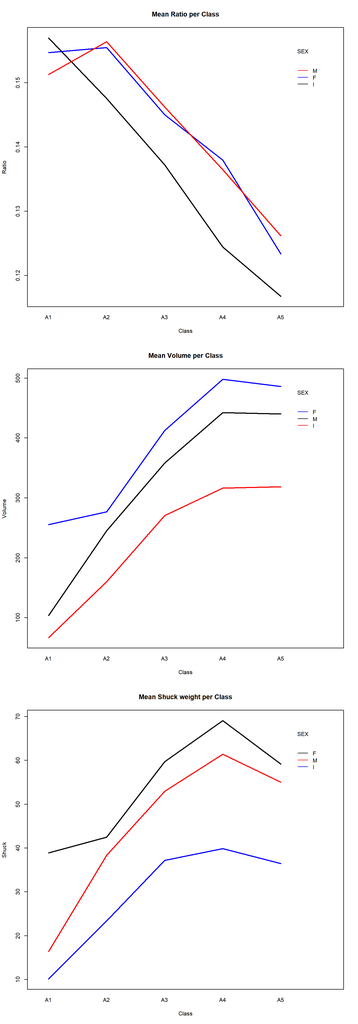

**Essay Question : What questions do these plots raise? Consider aging and sex differences.**

*Answer: Does the tissue/meat mostly contribute to the overall size of an abalone instead of the shell? For example, the RATIO plot reveals a significant decline in RATIO with CLASS. But the VOLUME and SHUCK plots reveal a positive upward trending correlation with CLASS.*

5(c) Present four boxplots using *par(mfrow = c(2, 2)* or *grid.arrange()*. The first line should show VOLUME by RINGS for the infants and, separately, for the adult; factor levels “M” and “F,” combined. The second line should show WHOLE by RINGS for the infants and, separately, for the adults. Since the data are sparse beyond 15 rings, limit the displays to less than 16 rings. One way to accomplish this is to generate a new data set using subset() to select RINGS < 16. Use ylim = c(0, 1100) for VOLUME and ylim = c(0, 400) for WHOLE. If you wish to reorder the displays for presentation purposes or use ggplot2 go ahead.

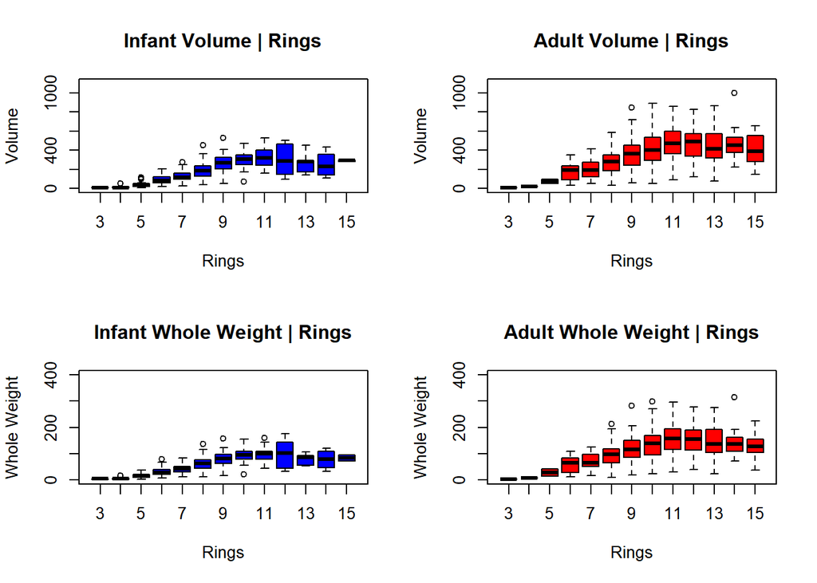

**Essay Question : What do these displays suggest about abalone growth? Also, compare the infant and adult displays. What differences stand out?**

*Answer: For the most part, these displays reveal that there is a positive correlation between RINGs and VOLUME and WHOLE weight for both adults and INFANTs. In other words, as RINGs increase, VOLUME and WHOLE weight increase as well.*

*Adults are larger in volume and whole weight than Infant and although Adults grow larger than Infants, they both appear to have identical growth rate trends. In fact, the growth rate for Infants and Adults has similar trends as they both begin to plateau after 10 Rings and then decline after 11 Rings.*

*However, it is interesting to note that although both appear to have similar growth rate trends, the size of Adults has a much larger standard deviation than Infants. For example, Adults vary in size more than Infants in both Volume and Whole weight, as revealed by the whiskers on the boxplots (the adults have large whiskers compared to the INFANTs). The Volume and Whole weight of Infants, on the other hand, are closer to the mean, indicating further investigation into the growth rates of each.*

*### Section 6: (11 points) Conclusions from the Exploratory Data Analysis (EDA).*

**Conclusions**

**Essay Question 1) Based solely on these data, what are plausible statistical reasons that explain the failure of the original study? Consider to what extent physical measurements may be used for age prediction.**

*Answer: At first glance, the physical measurements appeared to provide a decent predictor of age, but only to a limited extent. For example, as Volume and Weight increased, Rings increased as well. From this, overall size appears to be correlated with the number of Rings, however, it was confusing that abalone classified as Infants could have 15-20 Rings, the same number of Rings as an old Adult abalone. This did not make sense and ultimately made it difficult to rely upon a physical measurement, like Rings, as an age predictor. In other words, the data failed to be reliable because it was not consistent and did not reach normality.*

*Moreover, considering how sexing abalone is already known to be difficult and environmental variation and nutrient availability are known to be significant factors in abalone growth and maturation rates, the many outliers and the right skewed data seem to indicate that there may be issues with the harvesting and sampling procedures. These inconsistencies compel a reexamination of the classification/sampling procedures. Perhaps more variables should be introduced into the analyses, such as environmental factors of growth like weather, pollution, disease, loss of habitat, predation, etc.*

*Also, considering how diameter, height, length, and whole weight and volume are similar types of measurements, this may have caused structural and/or data multicollinearity. Perhaps Variance Inflation Factors (VIF) could be used to test and confirm the presence of multicollinearity. If there is multicollinearity, a few methods may be introduced to remove it, such as removing some of the highly correlated independent variables, linearly combining the independent variables, performing a principal components analysis, or performing a partial least squares regression analysis.*

**Essay Question 2) Do not refer to the abalone data or study. If you were presented with an overall histogram and summary statistics from a sample of some population or phenomenon and no other information, what questions might you ask before accepting them as representative of the sampled population or phenomenon?**

*Answer: What was your control? What are the confidence intervals? How was the sample obtained? What are the sampling and classification procedures? Where was the sample obtained? What is the population size? How does the sample size compare to the population size? In other words, is the sample size big enough to be an accurate representation of the population? What is the mean of the sample distribution compared to the population mean? What is the standard deviation of the sample distribution compared to the population standard deviation? Are there any similar studies performed in the past? If so, how does it compare with the prior studies, such as the sampling and classification procedures and methodologies? Is the sample randomized enough? Was the data modified in any way? Is it possible to obtain a copy of the raw data and the data cleaning steps?*

**Essay Question 3) Do not refer to the abalone data or study. What do you see as difficulties analyzing data derived from observational studies? Can causality be determined? What might be learned from such studies?**

*Answer: It is difficult to analyze data derived from observational studies because they are more prone to errors due to the manual/human nature of recording the data and the possibility of human biases from those collecting and analyzing the data. Observational studies are also more prone to having multicollinearity which requires additional steps to correct them, or the need to procure new variables to achieve normality.*

*It is very difficult to determine causality with observational data because external factors cannot be controlled. From this, it is very difficult to derive insights about a population or make all-inclusive claims about the population from a sample study. For example, observational data of animal habitat behavior over the last 2 months after a major flood, fire, or epidemic, will result in drastically different data than animal habitat behavior before the major event happened.*

*Since it is very difficult, if not impossible, to control external factors in observational studies, it is important to learn that observational studies should be seen as simply observations meant to gather insights about the relationship between independent and dependent variables. In other words, observational studies should be used as a tool to identify certain correlations to arouse interest of the subject matter for further investigation of the causality, in a separate more controlled study.*